# Pratical HM 3

## Practical Homework 3

#### Helen Liu

```python
# Import libraries

import numpy as np
import tensorflow as tf
import librosa
import random
import h5py

import matplotlib.pyplot as plt

from sklearn.model_selection import train_test_split
from sklearn.utils.class_weight import compute_class_weight
from sklearn.metrics import confusion_matrix, ConfusionMatrixDisplay, classification_report

from tensorflow.keras import regularizers

from keras.models import Sequential
from keras.layers import Dense, Dropout, Conv2D, MaxPooling2D, Flatten
from keras.utils import to_categorical
```

```python
#read data
f = h5py.File('/Users/helenliu/Downloads/bird_spectrograms.hdf5', 'r')
species_key_from_list = list(f.keys())
print(species_key_from_list)

for species in species_key_from_list:
     print(species, f[species].shape)
```

```
['amecro', 'amerob', 'bewwre', 'bkcchi', 'daejun', 'houfin', 'houspa', 'norfli', 'rewbla', 'sonspa', 'spotow', 'whcspa']
amecro (128, 517, 66)
amerob (128, 517, 172)
bewwre (128, 517, 144)
bkcchi (128, 517, 45)
daejun (128, 517, 125)
houfin (128, 517, 84)
houspa (128, 517, 630)
norfli (128, 517, 37)
rewbla (128, 517, 187)
sonspa (128, 517, 263)
spotow (128, 517, 137)
whcspa (128, 517, 91)
```

#### Binary Model:

I listened to example recordings from Xeno-canto to choose a pair of species for the binary classification model task. I selected *amerob* (American Robin) and *bewwre* (Bewick's Wren) for my binary model, because their singing sound somewhat similar to me, making the classification task more meaningful. in addition, both species have enough spectrogram samples in the dataset, and their sample sizes are similar, which helped keep the two classes reasonably balanced. First, a small binary dataset with random 100 spectrograms from *amerob* and 100 spectrograms from *bewwre* was created, to test model structure/depth and hyperparameters. This dataset was further split into a training (70%) and a test (30%) dataset.

```python
#smaller sample of binary dataset
random.seed(1)
np.random.seed(1)
tf.random.set_seed(1)

species_pair = ["amerob", "bewwre"]
n_per_species = 100

x_list = []
y_list = []

for label, species in enumerate (species_pair):
     data = f[species]
     print(species, "original shape:", data.shape)
     n_available = data.shape[2]
     #randomyl select 100 spectrograms from each species
     selected_indices = np.random.choice(n_available, size = n_per_species, replace = False)
     selected_indices = np.sort(selected_indices)
     selected_data = data[:, :, selected_indices]
     #move sample dimension to the front
     selected_data = np.moveaxis(selected_data, 2, 0)

     x_list.append(selected_data)
     y_list.extend([label]* n_per_species)

#combine into one dataset
x = np.concatenate(x_list, axis=0)
y = np.array(y_list)

print("Combined x shape:", x.shape)
print("Combined y shape:", y.shape)
print("Class counts:", np.bincount(y))
```

```
amerob original shape: (128, 517, 172)
bewwre original shape: (128, 517, 144)
Combined x shape: (200, 128, 517)
Combined y shape: (200,)
Class counts: [100 100]
```

```python
#scale image to [0,1] range
x = x.astype("float32")
x = (x - x.min()) / (x.max() - x.min())

# Add channel dimension for grayscale images as (200, 128, 517, 1)
x = np.expand_dims(x, axis=-1)

#split into training (70%) and test (30%) sets
x_train, x_test, y_train, y_test = train_test_split(x, y, test_size=0.30, random_state=123, stratify=y)

print("x_train shape:", x_train.shape)
print("x_test shape:", x_test.shape)
print("y_train shape:", y_train.shape)
print("y_test shape:", y_test.shape)
print("Training class counts:", np.bincount(y_train))
print("Test class counts:", np.bincount(y_test))
```

```
x_train shape: (140, 128, 517, 1)
x_test shape: (60, 128, 517, 1)
y_train shape: (140,)
y_test shape: (60,)
Training class counts: [70 70]
Test class counts: [30 30]
```

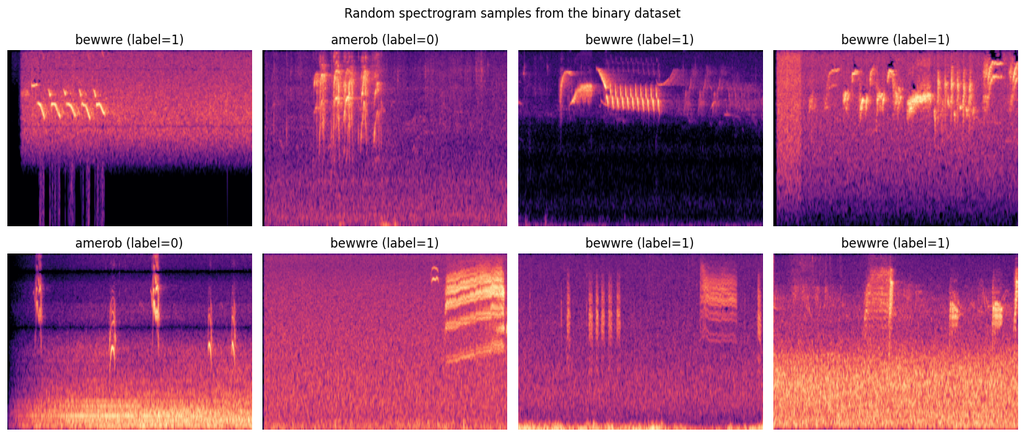

```python
# Visualize random spectrogram samples (robust to x shape)

label_names = species_pair  # ["amerob", "bewwre"]

n_samples = 8
indices = np.random.choice(x.shape[0], size=n_samples, replace=False)

fig, axes = plt.subplots(2, 4, figsize=(14, 6))
for ax, idx in zip(axes.flatten(), indices):
    if x.ndim == 4:
        img = x[idx, :, :, 0]
    elif x.ndim == 3:
        img = x[idx, :, :]
    else:
        raise ValueError(f"Unexpected x.ndim={x.ndim}")

    ax.imshow(img, aspect='auto', origin='lower', cmap='magma')
    ax.set_title(f"{label_names[y[idx]]} (label={y[idx]})")
    ax.axis('off')

plt.suptitle("Random spectrogram samples from the binary dataset")
plt.tight_layout()
plt.show()
```

Next, a 2-layer (then 4-, 6-, and 8-layer) CNN binary model was built.

```python
#2_layer model
np.random.seed(1)
tf.random.set_seed(1)

model_2 = Sequential([
    Conv2D(filters=16, kernel_size=(3, 3), padding="same", activation="relu", input_shape=x_train.shape[1:]),
    MaxPooling2D(pool_size=(2, 2)),
    Flatten(),
    Dropout(rate=0.3),
    Dense(units=64, activation="relu"),
    Dense(units=1, activation="sigmoid")])

model_2.summary()
```

```
Model: "sequential_2"
```

```
┏━━━━━━━━━━━━━━━━━━━━━━━━━━━━━━━━━┳━━━━━━━━━━━━━━━━━━━━━━━━┳━━━━━━━━━━━━━━━┓
┃ Layer (type)                    ┃ Output Shape           ┃       Param # ┃
┡━━━━━━━━━━━━━━━━━━━━━━━━━━━━━━━━━╇━━━━━━━━━━━━━━━━━━━━━━━━╇━━━━━━━━━━━━━━━┩
│ conv2d_2 (Conv2D)               │ (None, 128, 517, 16)   │           160 │
├─────────────────────────────────┼────────────────────────┼───────────────┤
│ max_pooling2d_2 (MaxPooling2D)  │ (None, 64, 258, 16)    │             0 │
├─────────────────────────────────┼────────────────────────┼───────────────┤
│ flatten_2 (Flatten)             │ (None, 264192)         │             0 │
├─────────────────────────────────┼────────────────────────┼───────────────┤
│ dropout_2 (Dropout)             │ (None, 264192)         │             0 │
├─────────────────────────────────┼────────────────────────┼───────────────┤
│ dense_4 (Dense)                 │ (None, 64)             │    16,908,352 │
├─────────────────────────────────┼────────────────────────┼───────────────┤
│ dense_5 (Dense)                 │ (None, 1)              │            65 │
└─────────────────────────────────┴────────────────────────┴───────────────┘
```

```
 Total params: 16,908,577 (64.50 MB)
```

```
 Trainable params: 16,908,577 (64.50 MB)
```

```
 Non-trainable params: 0 (0.00 B)
```

```python
%%time

model_2.compile(loss='binary_crossentropy',
                  optimizer='rmsprop',
                  metrics=['accuracy'])

history_2 = model_2.fit(x_train, y_train,
            epochs=10,
            batch_size=16,
            validation_split=0.2,
            verbose=0)

train_score_2 = model_2.evaluate(x_train, y_train, verbose=0)
test_score_2 = model_2.evaluate(x_test, y_test, verbose=0)

print("Training Accuracy: {:.2f}%".format(train_score_2[1] * 100))
print("Training Error: {:.2f}%".format((1 - train_score_2[1]) * 100))
print("Test Accuracy: {:.2f}%".format(test_score_2[1] * 100))
print("Test Error: {:.2f}%".format((1 - test_score_2[1]) * 100))
```

```
Training Accuracy: 58.57%
Training Error: 41.43%
Test Accuracy: 51.67%
Test Error: 48.33%
CPU times: user 31.7 s, sys: 4.69 s, total: 36.4 s
Wall time: 7.34 s
```

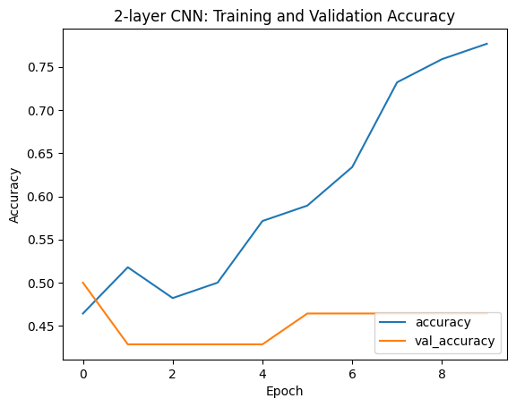

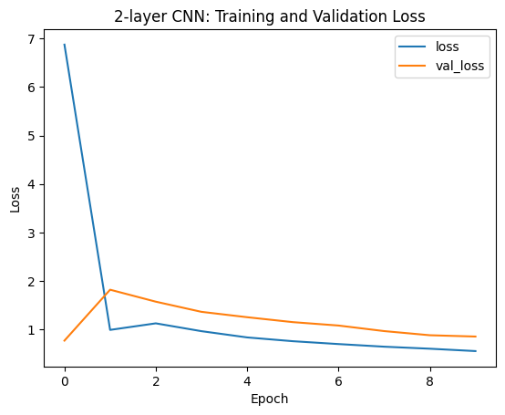

```python
plt.plot(history_2.history["accuracy"])
plt.plot(history_2.history["val_accuracy"])
plt.xlabel("Epoch")
plt.ylabel("Accuracy")
plt.legend(['accuracy', 'val_accuracy'], loc='lower right')
plt.title("2-layer CNN: Training and Validation Accuracy")
plt.show()

plt.plot(history_2.history["loss"])
plt.plot(history_2.history["val_loss"])
plt.xlabel("Epoch")
plt.ylabel("Loss")
plt.legend(['loss', 'val_loss'], loc='upper right')
plt.title("2-layer CNN: Training and Validation Loss")
plt.show()
```

Based on the plots above, for the 2-layer CNN model, training accuracy increased steadily with epochs increased, but the calidation accuracy stayed around 43%-50%, which is close to random guessing for a binacy classificaion (50%). The error rate on the test set is 48.33%. These results may suggest that the 2-layer model did not perform well on unseen data and is probably too simple for a spectrongram classification.

A 4-layer CNN model was fitted next.

```python
#4_layer model
np.random.seed(1)
tf.random.set_seed(1)

model_4 = Sequential([
    Conv2D(filters=16, kernel_size=(3, 3), padding="same", activation="relu", input_shape=x_train.shape[1:]),
    MaxPooling2D(pool_size=(2, 2)),
    Conv2D(filters=32, kernel_size=(3, 3), padding="same", activation="relu"),
    MaxPooling2D(pool_size=(2, 2)),
    Flatten(),
    Dropout(rate=0.3),
    Dense(units=64, activation="relu"),
    Dense(units=1, activation="sigmoid")])

model_4.summary()
```

```
Model: "sequential_31"
```

```
┏━━━━━━━━━━━━━━━━━━━━━━━━━━━━━━━━━┳━━━━━━━━━━━━━━━━━━━━━━━━┳━━━━━━━━━━━━━━━┓
┃ Layer (type)                    ┃ Output Shape           ┃       Param # ┃
┡━━━━━━━━━━━━━━━━━━━━━━━━━━━━━━━━━╇━━━━━━━━━━━━━━━━━━━━━━━━╇━━━━━━━━━━━━━━━┩
│ conv2d_87 (Conv2D)              │ (None, 128, 517, 16)   │           160 │
├─────────────────────────────────┼────────────────────────┼───────────────┤
│ max_pooling2d_87 (MaxPooling2D) │ (None, 64, 258, 16)    │             0 │
├─────────────────────────────────┼────────────────────────┼───────────────┤
│ conv2d_88 (Conv2D)              │ (None, 64, 258, 32)    │         4,640 │
├─────────────────────────────────┼────────────────────────┼───────────────┤
│ max_pooling2d_88 (MaxPooling2D) │ (None, 32, 129, 32)    │             0 │
├─────────────────────────────────┼────────────────────────┼───────────────┤
│ flatten_31 (Flatten)            │ (None, 132096)         │             0 │
├─────────────────────────────────┼────────────────────────┼───────────────┤
│ dropout_31 (Dropout)            │ (None, 132096)         │             0 │
├─────────────────────────────────┼────────────────────────┼───────────────┤
│ dense_62 (Dense)                │ (None, 64)             │     8,454,208 │
├─────────────────────────────────┼────────────────────────┼───────────────┤
│ dense_63 (Dense)                │ (None, 1)              │            65 │
└─────────────────────────────────┴────────────────────────┴───────────────┘
```

```
 Total params: 8,459,073 (32.27 MB)
```

```
 Trainable params: 8,459,073 (32.27 MB)
```

```
 Non-trainable params: 0 (0.00 B)
```

```python
%%time

model_4.compile(loss='binary_crossentropy',
                  optimizer='rmsprop',
                  metrics=['accuracy'])

history_4 = model_4.fit(x_train, y_train,
            epochs=10,
            batch_size=16,
            validation_split=0.2,
            verbose=0)

train_score_4 = model_4.evaluate(x_train, y_train, verbose=0)
test_score_4 = model_4.evaluate(x_test, y_test, verbose=0)

print("Training Accuracy: {:.2f}%".format(train_score_4[1] * 100))
print("Training Error: {:.2f}%".format((1 - train_score_4[1]) * 100))
print("Test Accuracy: {:.2f}%".format(test_score_4[1] * 100))
print("Test Error: {:.2f}%".format((1 - test_score_4[1]) * 100))
```

```
Training Accuracy: 69.29%
Training Error: 30.71%
Test Accuracy: 50.00%
Test Error: 50.00%
CPU times: user 43.7 s, sys: 4.43 s, total: 48.2 s
Wall time: 9.93 s
```

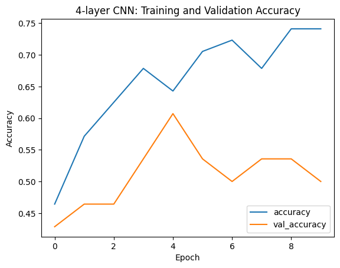

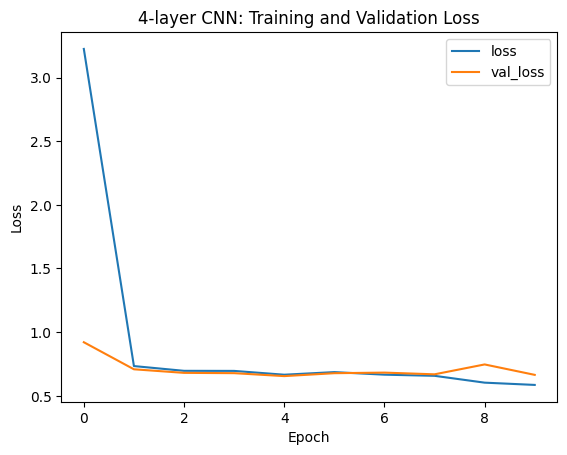

```python
plt.plot(history_4.history["accuracy"])
plt.plot(history_4.history["val_accuracy"])
plt.xlabel("Epoch")
plt.ylabel("Accuracy")
plt.legend(['accuracy', 'val_accuracy'], loc='lower right')
plt.title("4-layer CNN: Training and Validation Accuracy")
plt.show()

plt.plot(history_4.history["loss"])
plt.plot(history_4.history["val_loss"])
plt.xlabel("Epoch")
plt.ylabel("Loss")
plt.legend(['loss', 'val_loss'], loc='upper right')
plt.title("4-layer CNN: Training and Validation Loss")
plt.show()
```

For the 4-layer CNN model, the loss plot above suggest that the model appears to converge, as both training and validation loss decreased then stabilized. Although the training accuracy increased overall, the validation accuracy flactuated a lot and around 0.5-0.6. The test error was also very high (50.00%), just like random guessing for a balanced binary classification. These results suggest that the 4-layer model did not learn well enough to predict unseen spectorgrams.

A 6-layer model was fitted next.

```python
#6_layer model
np.random.seed(1)
tf.random.set_seed(1)

model_6 = Sequential([
    Conv2D(filters=16, kernel_size=(3, 3), padding="same", activation="relu", input_shape=x_train.shape[1:]),
    MaxPooling2D(pool_size=(2, 2)),
    Conv2D(filters=32, kernel_size=(3, 3), padding="same", activation="relu"),
    MaxPooling2D(pool_size=(2, 2)),
    Conv2D(filters=64, kernel_size=(3, 3), padding="same", activation="relu"),
    MaxPooling2D(pool_size=(2, 2)),
    Flatten(),
    Dropout(rate=0.3),
    Dense(units=64, activation="relu"),
    Dense(units=1, activation="sigmoid")])

model_6.summary()
```

```
Model: "sequential_32"
```

```
┏━━━━━━━━━━━━━━━━━━━━━━━━━━━━━━━━━┳━━━━━━━━━━━━━━━━━━━━━━━━┳━━━━━━━━━━━━━━━┓
┃ Layer (type)                    ┃ Output Shape           ┃       Param # ┃
┡━━━━━━━━━━━━━━━━━━━━━━━━━━━━━━━━━╇━━━━━━━━━━━━━━━━━━━━━━━━╇━━━━━━━━━━━━━━━┩
│ conv2d_89 (Conv2D)              │ (None, 128, 517, 16)   │           160 │
├─────────────────────────────────┼────────────────────────┼───────────────┤
│ max_pooling2d_89 (MaxPooling2D) │ (None, 64, 258, 16)    │             0 │
├─────────────────────────────────┼────────────────────────┼───────────────┤
│ conv2d_90 (Conv2D)              │ (None, 64, 258, 32)    │         4,640 │
├─────────────────────────────────┼────────────────────────┼───────────────┤
│ max_pooling2d_90 (MaxPooling2D) │ (None, 32, 129, 32)    │             0 │
├─────────────────────────────────┼────────────────────────┼───────────────┤
│ conv2d_91 (Conv2D)              │ (None, 32, 129, 64)    │        18,496 │
├─────────────────────────────────┼────────────────────────┼───────────────┤
│ max_pooling2d_91 (MaxPooling2D) │ (None, 16, 64, 64)     │             0 │
├─────────────────────────────────┼────────────────────────┼───────────────┤
│ flatten_32 (Flatten)            │ (None, 65536)          │             0 │
├─────────────────────────────────┼────────────────────────┼───────────────┤
│ dropout_32 (Dropout)            │ (None, 65536)          │             0 │
├─────────────────────────────────┼────────────────────────┼───────────────┤
│ dense_64 (Dense)                │ (None, 64)             │     4,194,368 │
├─────────────────────────────────┼────────────────────────┼───────────────┤
│ dense_65 (Dense)                │ (None, 1)              │            65 │
└─────────────────────────────────┴────────────────────────┴───────────────┘
```

```
 Total params: 4,217,729 (16.09 MB)
```

```
 Trainable params: 4,217,729 (16.09 MB)
```

```
 Non-trainable params: 0 (0.00 B)
```

```python
%%time

model_6.compile(loss='binary_crossentropy',
                  optimizer='rmsprop',
                  metrics=['accuracy'])

history_6 = model_6.fit(x_train, y_train,
            epochs=10,
            batch_size=16,
            validation_split=0.2,
            verbose=0)

train_score_6 = model_6.evaluate(x_train, y_train, verbose=0)
test_score_6 = model_6.evaluate(x_test, y_test, verbose=0)

print("Training Accuracy: {:.2f}%".format(train_score_6[1] * 100))
print("Training Error: {:.2f}%".format((1 - train_score_6[1]) * 100))
print("Test Accuracy: {:.2f}%".format(test_score_6[1] * 100))
print("Test Error: {:.2f}%".format((1 - test_score_6[1]) * 100))
```

```
Training Accuracy: 65.71%
Training Error: 34.29%
Test Accuracy: 53.33%
Test Error: 46.67%
CPU times: user 55.3 s, sys: 5.05 s, total: 1min
Wall time: 11.1 s
```

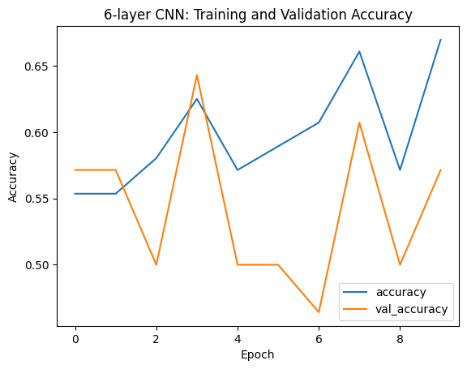

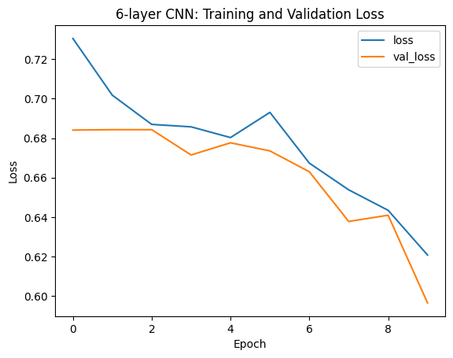

```python
plt.plot(history_6.history["accuracy"])
plt.plot(history_6.history["val_accuracy"])
plt.xlabel("Epoch")
plt.ylabel("Accuracy")
plt.legend(['accuracy', 'val_accuracy'], loc='lower right')
plt.title("6-layer CNN: Training and Validation Accuracy")
plt.show()

plt.plot(history_6.history["loss"])
plt.plot(history_6.history["val_loss"])
plt.xlabel("Epoch")
plt.ylabel("Loss")
plt.legend(['loss', 'val_loss'], loc='upper right')
plt.title("6-layer CNN: Training and Validation Loss")
plt.show()
```

The 6-layer CNN model had a test error of 46.67%, which is still very high (close to random guess). The loss plot demonstrated the the training and validation loss decreased as epoch increased. However, training and validation accuracy curves were still unstable and flactuated a lot. This may due to the small validation set (0.2*140 = 28). These results suggested that the 6-layer model did not learn features well to predict unseen spectrograms accurately.

Next, a 8-layer model was fitted.

```python
#8_layer model
np.random.seed(1)
tf.random.set_seed(1)

model_8 = Sequential([
    Conv2D(filters=16, kernel_size=(3, 3), padding="same", activation="relu", input_shape=x_train.shape[1:]),
    MaxPooling2D(pool_size=(2, 2)),
    Conv2D(filters=32, kernel_size=(3, 3), padding="same", activation="relu"),
    MaxPooling2D(pool_size=(2, 2)),
    Conv2D(filters=64, kernel_size=(3, 3), padding="same", activation="relu"),
    MaxPooling2D(pool_size=(2, 2)),
    Conv2D(filters=128, kernel_size=(3, 3), padding="same", activation="relu"),
    MaxPooling2D(pool_size=(2, 2)),
    Flatten(),
    Dropout(rate=0.3),
    Dense(units=64, activation="relu"),
    Dense(units=1, activation="sigmoid")])

model_8.summary()
```

```
Model: "sequential_33"
```

```
┏━━━━━━━━━━━━━━━━━━━━━━━━━━━━━━━━━┳━━━━━━━━━━━━━━━━━━━━━━━━┳━━━━━━━━━━━━━━━┓
┃ Layer (type)                    ┃ Output Shape           ┃       Param # ┃
┡━━━━━━━━━━━━━━━━━━━━━━━━━━━━━━━━━╇━━━━━━━━━━━━━━━━━━━━━━━━╇━━━━━━━━━━━━━━━┩
│ conv2d_92 (Conv2D)              │ (None, 128, 517, 16)   │           160 │
├─────────────────────────────────┼────────────────────────┼───────────────┤
│ max_pooling2d_92 (MaxPooling2D) │ (None, 64, 258, 16)    │             0 │
├─────────────────────────────────┼────────────────────────┼───────────────┤
│ conv2d_93 (Conv2D)              │ (None, 64, 258, 32)    │         4,640 │
├─────────────────────────────────┼────────────────────────┼───────────────┤
│ max_pooling2d_93 (MaxPooling2D) │ (None, 32, 129, 32)    │             0 │
├─────────────────────────────────┼────────────────────────┼───────────────┤
│ conv2d_94 (Conv2D)              │ (None, 32, 129, 64)    │        18,496 │
├─────────────────────────────────┼────────────────────────┼───────────────┤
│ max_pooling2d_94 (MaxPooling2D) │ (None, 16, 64, 64)     │             0 │
├─────────────────────────────────┼────────────────────────┼───────────────┤
│ conv2d_95 (Conv2D)              │ (None, 16, 64, 128)    │        73,856 │
├─────────────────────────────────┼────────────────────────┼───────────────┤
│ max_pooling2d_95 (MaxPooling2D) │ (None, 8, 32, 128)     │             0 │
├─────────────────────────────────┼────────────────────────┼───────────────┤
│ flatten_33 (Flatten)            │ (None, 32768)          │             0 │
├─────────────────────────────────┼────────────────────────┼───────────────┤
│ dropout_33 (Dropout)            │ (None, 32768)          │             0 │
├─────────────────────────────────┼────────────────────────┼───────────────┤
│ dense_66 (Dense)                │ (None, 64)             │     2,097,216 │
├─────────────────────────────────┼────────────────────────┼───────────────┤
│ dense_67 (Dense)                │ (None, 1)              │            65 │
└─────────────────────────────────┴────────────────────────┴───────────────┘
```

```
 Total params: 2,194,433 (8.37 MB)
```

```
 Trainable params: 2,194,433 (8.37 MB)
```

```
 Non-trainable params: 0 (0.00 B)
```

```python
%%time

model_8.compile(loss='binary_crossentropy',
                  optimizer='rmsprop',
                  metrics=['accuracy'])

history_8 = model_8.fit(x_train, y_train,
            epochs=10,
            batch_size=16,
            validation_split=0.2,
            verbose=0)

train_score_8 = model_8.evaluate(x_train, y_train, verbose=0)
test_score_8 = model_8.evaluate(x_test, y_test, verbose=0)

print("Training Accuracy: {:.2f}%".format(train_score_8[1] * 100))
print("Training Error: {:.2f}%".format((1 - train_score_8[1]) * 100))
print("Test Accuracy: {:.2f}%".format(test_score_8[1] * 100))
print("Test Error: {:.2f}%".format((1 - test_score_8[1]) * 100))
```

```
Training Accuracy: 72.14%
Training Error: 27.86%
Test Accuracy: 68.33%
Test Error: 31.67%
CPU times: user 1min 6s, sys: 5.91 s, total: 1min 12s
Wall time: 13.8 s
```

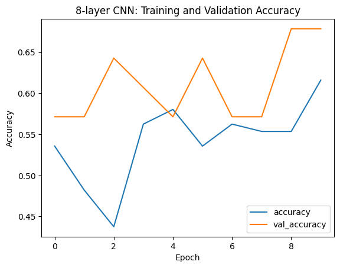

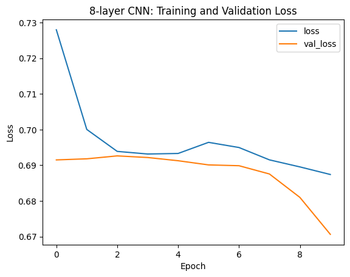

```python
plt.plot(history_8.history["accuracy"])
plt.plot(history_8.history["val_accuracy"])
plt.xlabel("Epoch")
plt.ylabel("Accuracy")
plt.legend(['accuracy', 'val_accuracy'], loc='lower right')
plt.title("8-layer CNN: Training and Validation Accuracy")
plt.show()

plt.plot(history_8.history["loss"])
plt.plot(history_8.history["val_loss"])
plt.xlabel("Epoch")
plt.ylabel("Loss")
plt.legend(['loss', 'val_loss'], loc='upper right')
plt.title("8-layer CNN: Training and Validation Loss")
plt.show()
```

The 8-layer model produced a test error of 31.67%, which is lower than 2-, 4-, and 6-layer models, suggesting that additional layers helped the model learn more useful features from the spectrogram. However, the validation accuracy remained unstable, and the loss decreased only slightly, suggesting that the model may not fully converge to a stable classifier. The instability may be partly due to the small training and validation samples.

```python
#10_layer model
np.random.seed(1)
tf.random.set_seed(1)

model_10 = Sequential([
    Conv2D(filters=16, kernel_size=(3, 3), padding="same", activation="relu", input_shape=x_train.shape[1:]),
    MaxPooling2D(pool_size=(2, 2)),
    Conv2D(filters=32, kernel_size=(3, 3), padding="same", activation="relu"),
    MaxPooling2D(pool_size=(2, 2)),
    Conv2D(filters=64, kernel_size=(3, 3), padding="same", activation="relu"),
    MaxPooling2D(pool_size=(2, 2)),
    Conv2D(filters=128, kernel_size=(3, 3), padding="same", activation="relu"),
    MaxPooling2D(pool_size=(2, 2)),
    Conv2D(filters=256, kernel_size=(3, 3), padding="same", activation="relu"),
    MaxPooling2D(pool_size=(2, 2)),
    Flatten(),
    Dropout(rate=0.3),
    Dense(units=64, activation="relu"),
    Dense(units=1, activation="sigmoid")])


model_10.compile(loss='binary_crossentropy',
                  optimizer='rmsprop',
                  metrics=['accuracy'])

history_10 = model_10.fit(x_train, y_train,
            epochs=10,
            batch_size=16,
            validation_split=0.2,
            verbose=0)

train_score_10 = model_10.evaluate(x_train, y_train, verbose=0)
test_score_10 = model_10.evaluate(x_test, y_test, verbose=0)

print("Training Accuracy: {:.2f}%".format(train_score_10[1] * 100))
print("Training Error: {:.2f}%".format((1 - train_score_10[1]) * 100))
print("Test Accuracy: {:.2f}%".format(test_score_10[1] * 100))
print("Test Error: {:.2f}%".format((1 - test_score_10[1]) * 100))
```

```
Training Accuracy: 67.14%
Training Error: 32.86%
Test Accuracy: 58.33%
Test Error: 41.67%
```

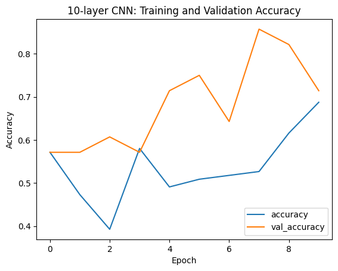

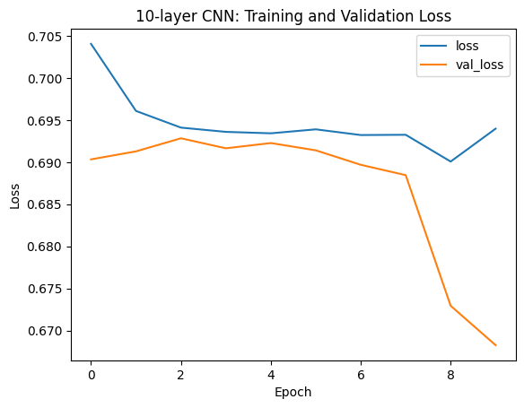

```python
plt.plot(history_10.history["accuracy"])
plt.plot(history_10.history["val_accuracy"])
plt.xlabel("Epoch")
plt.ylabel("Accuracy")
plt.legend(['accuracy', 'val_accuracy'], loc='lower right')
plt.title("10-layer CNN: Training and Validation Accuracy")
plt.show()

plt.plot(history_10.history["loss"])
plt.plot(history_10.history["val_loss"])
plt.xlabel("Epoch")
plt.ylabel("Loss")
plt.legend(['loss', 'val_loss'], loc='upper right')
plt.title("10-layer CNN: Training and Validation Loss")
plt.show()
```

A 10-layer model was tested to see whether adding more convolution -pooling blocks would improve the binary model. However, the test error increased to 41.67%, and the training/validation curves remained unstable. The loss values stayed close to 0.69, suggesting weak classification performance. These results indicated that simply increasing network depth did not improve the model for this dataset.

Hence, I selected the 8-layer model as the most promising model structure, and focused later tuning on other hyperparameters on the full dataset (sample size = 172+144 = 316) to improve model performance.

```python
#prepare full dataset (amerob + bewwre) for binary model
random.seed(1)
np.random.seed(1)
tf.random.set_seed(1)

species_pair = ["amerob", "bewwre"]

x_list = []
y_list = []

for label, species in enumerate (species_pair):
     data = f[species]
     print(species, "original shape:", data.shape)
     selected_data = data[:, :, :]
     #move sample dimension to the front
     selected_data = np.moveaxis(selected_data, 2, 0)

     x_list.append(selected_data)
     y_list.extend([label]* selected_data.shape[0])

#combine into one dataset
x_full = np.concatenate(x_list, axis=0)
y_full = np.array(y_list)

print("Combined full_x shape:", x_full.shape)
print("Combined full_y shape:", y_full.shape)
print("Class counts:", np.bincount(y_full))
```

```
amerob original shape: (128, 517, 172)
bewwre original shape: (128, 517, 144)
Combined full_x shape: (316, 128, 517)
Combined full_y shape: (316,)
Class counts: [172 144]
```

```python
#scale image to [0,1] range
x_full = x_full.astype("float32")
x_full = (x_full - x_full.min()) / (x_full.max() - x_full.min())

# Add channel dimension for grayscale images as (316, 128, 517, 1)
x_full = np.expand_dims(x_full, axis=-1)

#split into training (70%) and test (30%) sets
x_full_train, x_full_test, y_full_train, y_full_test = train_test_split(x_full, y_full, test_size=0.30, random_state=1, stratify=y_full)

print("x_full_train shape:", x_full_train.shape)
print("x_full_test shape:", x_full_test.shape)
print("y_full_train shape:", y_full_train.shape)
print("y_full_test shape:", y_full_test.shape)
print("Training class counts:", np.bincount(y_full_train))
print("Test class counts:", np.bincount(y_full_test))
```

```
x_full_train shape: (221, 128, 517, 1)
x_full_test shape: (95, 128, 517, 1)
y_full_train shape: (221,)
y_full_test shape: (95,)
Training class counts: [120 101]
Test class counts: [52 43]
```

```python
%%time

#fine tune the 8-layer CNN model
np.random.seed(1)
tf.random.set_seed(1)

model_8A = Sequential([
    Conv2D(filters=16, kernel_size=(3, 3), padding="same", activation="relu", input_shape=x_full_train.shape[1:]),
    MaxPooling2D(pool_size=(2, 2)),
    Conv2D(filters=32, kernel_size=(3, 3), padding="same", activation="relu"),
    MaxPooling2D(pool_size=(2, 2)),
    Conv2D(filters=64, kernel_size=(3, 3), padding="same", activation="relu"),
    MaxPooling2D(pool_size=(2, 2)),
    Conv2D(filters=128, kernel_size=(3, 3), padding="same", activation="relu"),
    MaxPooling2D(pool_size=(2, 2)),
    Flatten(),
    Dropout(rate=0.3),
    Dense(units=64, activation="relu"),
    Dense(units=1, activation="sigmoid")])

model_8A.compile(loss='binary_crossentropy',
                  optimizer='rmsprop',
                  metrics=['accuracy'])

history_8A = model_8A.fit(x_full_train, y_full_train,
            epochs=10,
            batch_size=16,
            validation_split=0.2,
            verbose=0)

train_score_8A = model_8A.evaluate(x_full_train, y_full_train, verbose=0)
test_score_8A = model_8A.evaluate(x_full_test, y_full_test, verbose=0)

print("Training Accuracy: {:.2f}%".format(train_score_8A[1] * 100))
print("Training Error: {:.2f}%".format((1 - train_score_8A[1]) * 100))
print("Test Accuracy: {:.2f}%".format(test_score_8A[1] * 100))
print("Test Error: {:.2f}%".format((1 - test_score_8A[1]) * 100))
```

```
Training Accuracy: 84.62%
Training Error: 15.38%
Test Accuracy: 76.84%
Test Error: 23.16%
CPU times: user 1min 42s, sys: 7.37 s, total: 1min 50s
Wall time: 19.1 s
```

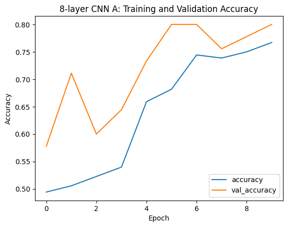

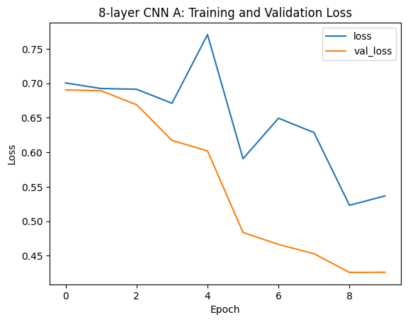

```python
plt.plot(history_8A.history["accuracy"])
plt.plot(history_8A.history["val_accuracy"])
plt.xlabel("Epoch")
plt.ylabel("Accuracy")
plt.legend(['accuracy', 'val_accuracy'], loc='lower right')
plt.title("8-layer CNN A: Training and Validation Accuracy")
plt.show()

plt.plot(history_8A.history["loss"])
plt.plot(history_8A.history["val_loss"])
plt.xlabel("Epoch")
plt.ylabel("Loss")
plt.legend(['loss', 'val_loss'], loc='upper right')
plt.title("8-layer CNN A: Training and Validation Loss")
plt.show()
```

```python
%%time

#increae dropout rate from 0.3 to 0.5
np.random.seed(1)
tf.random.set_seed(1)

model_8B = Sequential([
    Conv2D(filters=16, kernel_size=(3, 3), padding="same", activation="relu", input_shape=x_full_train.shape[1:]),
    MaxPooling2D(pool_size=(2, 2)),
    Conv2D(filters=32, kernel_size=(3, 3), padding="same", activation="relu"),
    MaxPooling2D(pool_size=(2, 2)),
    Conv2D(filters=64, kernel_size=(3, 3), padding="same", activation="relu"),
    MaxPooling2D(pool_size=(2, 2)),
    Conv2D(filters=128, kernel_size=(3, 3), padding="same", activation="relu"),
    MaxPooling2D(pool_size=(2, 2)),
    Flatten(),
    Dropout(rate=0.5),
    Dense(units=64, activation="relu"),
    Dense(units=1, activation="sigmoid")])

model_8B.compile(loss='binary_crossentropy',
                  optimizer='rmsprop',
                  metrics=['accuracy'])

history_8B = model_8B.fit(x_full_train, y_full_train,
            epochs=10,
            batch_size=16,
            validation_split=0.2,
            verbose=0)

train_score_8B = model_8B.evaluate(x_full_train, y_full_train, verbose=0)
test_score_8B = model_8B.evaluate(x_full_test, y_full_test, verbose=0)

print("Training Accuracy: {:.2f}%".format(train_score_8B[1] * 100))
print("Training Error: {:.2f}%".format((1 - train_score_8B[1]) * 100))
print("Test Accuracy: {:.2f}%".format(test_score_8B[1] * 100))
print("Test Error: {:.2f}%".format((1 - test_score_8B[1]) * 100))
```

```
Training Accuracy: 76.47%
Training Error: 23.53%
Test Accuracy: 71.58%
Test Error: 28.42%
CPU times: user 1min 41s, sys: 7.26 s, total: 1min 48s
Wall time: 19.4 s
```

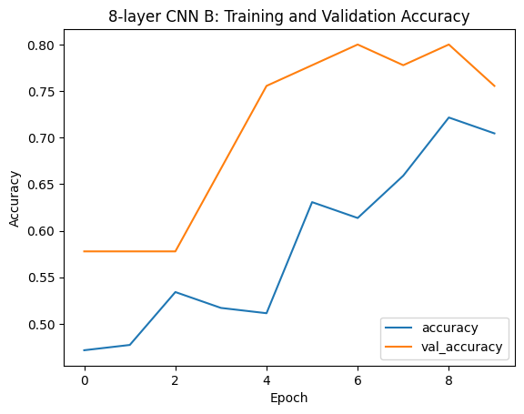

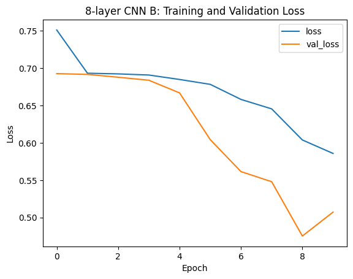

```python
plt.plot(history_8B.history["accuracy"])
plt.plot(history_8B.history["val_accuracy"])
plt.xlabel("Epoch")
plt.ylabel("Accuracy")
plt.legend(['accuracy', 'val_accuracy'], loc='lower right')
plt.title("8-layer CNN B: Training and Validation Accuracy")
plt.show()

plt.plot(history_8B.history["loss"])
plt.plot(history_8B.history["val_loss"])
plt.xlabel("Epoch")
plt.ylabel("Loss")
plt.legend(['loss', 'val_loss'], loc='upper right')
plt.title("8-layer CNN B: Training and Validation Loss")
plt.show()
```

The first two 8-layer models (Models 8A and 8B) tested different dropout rates (0.3 vs. 0.5). Model 8A had a test rate of 23.16%, which is slightly better than the test errors of Model 8B (28.42%). Although the validation/training loss decreased over time, the training and validation accuracy curves showed some instability for both models, likely because the dataset is relatively small. The results indicate that increasing dropout to 0.5 did not improve model performance. The dropout rate of 0.3 will be kept.

Next, differetn filter number setting were tested while keeping dropout = 0.3.

```python
%%time

#Model 8C: increase number of filters from 16/32/64/128 to 32/64/128/256
np.random.seed(1)
tf.random.set_seed(1)

model_8C = Sequential([
    Conv2D(filters=32, kernel_size=(3, 3), padding="same", activation="relu", input_shape=x_full_train.shape[1:]),
    MaxPooling2D(pool_size=(2, 2)),
    Conv2D(filters=64, kernel_size=(3, 3), padding="same", activation="relu"),
    MaxPooling2D(pool_size=(2, 2)),
    Conv2D(filters=128, kernel_size=(3, 3), padding="same", activation="relu"),
    MaxPooling2D(pool_size=(2, 2)),
    Conv2D(filters=256, kernel_size=(3, 3), padding="same", activation="relu"),
    MaxPooling2D(pool_size=(2, 2)),
    Flatten(),
    Dropout(rate=0.3),
    Dense(units=64, activation="relu"),
    Dense(units=1, activation="sigmoid")])

model_8C.compile(loss='binary_crossentropy',
                  optimizer='rmsprop',
                  metrics=['accuracy'])

history_8C = model_8C.fit(x_full_train, y_full_train,
            epochs=10,
            batch_size=16,
            validation_split=0.2,
            verbose=0)

train_score_8C = model_8C.evaluate(x_full_train, y_full_train, verbose=0)
test_score_8C = model_8C.evaluate(x_full_test, y_full_test, verbose=0)

print("Training Accuracy: {:.2f}%".format(train_score_8C[1] * 100))
print("Training Error: {:.2f}%".format((1 - train_score_8C[1]) * 100))
print("Test Accuracy: {:.2f}%".format(test_score_8C[1] * 100))
print("Test Error: {:.2f}%".format((1 - test_score_8C[1]) * 100))
```

```
Training Accuracy: 79.64%
Training Error: 20.36%
Test Accuracy: 72.63%
Test Error: 27.37%
CPU times: user 4min 41s, sys: 21.3 s, total: 5min 2s
Wall time: 48.7 s
```

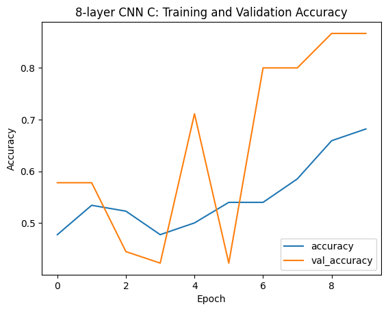

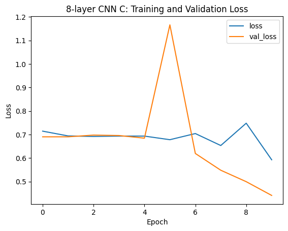

```python
plt.plot(history_8C.history["accuracy"])
plt.plot(history_8C.history["val_accuracy"])
plt.xlabel("Epoch")
plt.ylabel("Accuracy")
plt.legend(['accuracy', 'val_accuracy'], loc='lower right')
plt.title("8-layer CNN C: Training and Validation Accuracy")
plt.show()

plt.plot(history_8C.history["loss"])
plt.plot(history_8C.history["val_loss"])
plt.xlabel("Epoch")
plt.ylabel("Loss")
plt.legend(['loss', 'val_loss'], loc='upper right')
plt.title("8-layer CNN C: Training and Validation Loss")
plt.show()
```

```python
%%time

#Model 8D: increase number of filters to 64/128/256/512
np.random.seed(1)
tf.random.set_seed(1)

model_8D = Sequential([
    Conv2D(filters=64, kernel_size=(3, 3), padding="same", activation="relu", input_shape=x_full_train.shape[1:]),
    MaxPooling2D(pool_size=(2, 2)),
   Conv2D(filters=128, kernel_size=(3, 3), padding="same", activation="relu"),
    MaxPooling2D(pool_size=(2, 2)),
    Conv2D(filters=256, kernel_size=(3, 3), padding="same", activation="relu"),
    MaxPooling2D(pool_size=(2, 2)),
    Conv2D(filters=512, kernel_size=(3, 3), padding="same", activation="relu"),
    MaxPooling2D(pool_size=(2, 2)),
    Flatten(),
    Dropout(rate=0.3),
    Dense(units=64, activation="relu"),
    Dense(units=1, activation="sigmoid")])

model_8D.compile(loss='binary_crossentropy',
                  optimizer='rmsprop',
                  metrics=['accuracy'])

history_8D = model_8D.fit(x_full_train, y_full_train,
            epochs=10,
            batch_size=16,
            validation_split=0.2,
            verbose=0)

train_score_8D = model_8D.evaluate(x_full_train, y_full_train, verbose=0)
test_score_8D = model_8D.evaluate(x_full_test, y_full_test, verbose=0)

print("Training Accuracy: {:.2f}%".format(train_score_8D[1] * 100))
print("Training Error: {:.2f}%".format((1 - train_score_8D[1]) * 100))
print("Test Accuracy: {:.2f}%".format(test_score_8D[1] * 100))
print("Test Error: {:.2f}%".format((1 - test_score_8D[1]) * 100))
```

```
Training Accuracy: 78.73%
Training Error: 21.27%
Test Accuracy: 70.53%
Test Error: 29.47%
CPU times: user 15min 47s, sys: 49.7 s, total: 16min 37s
Wall time: 2min 28s
```

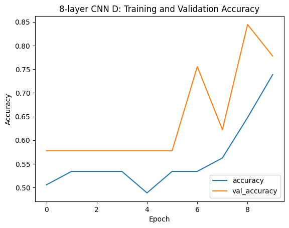

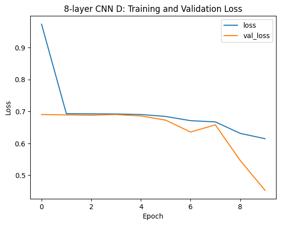

```python
plt.plot(history_8D.history["accuracy"])
plt.plot(history_8D.history["val_accuracy"])
plt.xlabel("Epoch")
plt.ylabel("Accuracy")
plt.legend(['accuracy', 'val_accuracy'], loc='lower right')
plt.title("8-layer CNN D: Training and Validation Accuracy")
plt.show()

plt.plot(history_8D.history["loss"])
plt.plot(history_8D.history["val_loss"])
plt.xlabel("Epoch")
plt.ylabel("Loss")
plt.legend(['loss', 'val_loss'], loc='upper right')
plt.title("8-layer CNN D: Training and Validation Loss")
plt.show()
```

Models 8C and 8D tested whether increasing the number of filters improved the 8-layer CNN model. The test errors were 27.37% for model 8C (using filter settings of 32/64/128/256) and 29.47% for model 6D (filter settings of 64/128/256/512), both are higher than 23.16% of model 8A (filter settings of 16/32/64/128). This suggested that additional model complexity was not useful for this dataset and may have made the model harder to train. Hence, the simpler 16/32/64/128 filter setting was kept for the binary model.

Next, a different dense value and batch size was tested.

```python
%%time

#Model 8E: increase Dense from 64 to 128
np.random.seed(1)
tf.random.set_seed(1)

model_8E = Sequential([
    Conv2D(filters=16, kernel_size=(3, 3), padding="same", activation="relu", input_shape=x_full_train.shape[1:]),
    MaxPooling2D(pool_size=(2, 2)),
    Conv2D(filters=32, kernel_size=(3, 3), padding="same", activation="relu"),
    MaxPooling2D(pool_size=(2, 2)),
    Conv2D(filters=64, kernel_size=(3, 3), padding="same", activation="relu"),
    MaxPooling2D(pool_size=(2, 2)),
    Conv2D(filters=128, kernel_size=(3, 3), padding="same", activation="relu"),
    MaxPooling2D(pool_size=(2, 2)),
    Flatten(),
    Dropout(rate=0.3),
    Dense(units=128, activation="relu"),
    Dense(units=1, activation="sigmoid")])

model_8E.compile(loss='binary_crossentropy',
                  optimizer='rmsprop',
                  metrics=['accuracy'])

history_8E = model_8E.fit(x_full_train, y_full_train,
            epochs=10,
            batch_size=16,
            validation_split=0.2,
            verbose=0)

train_score_8E = model_8E.evaluate(x_full_train, y_full_train, verbose=0)
test_score_8E = model_8E.evaluate(x_full_test, y_full_test, verbose=0)

print("Training Accuracy: {:.2f}%".format(train_score_8E[1] * 100))
print("Training Error: {:.2f}%".format((1 - train_score_8E[1]) * 100))
print("Test Accuracy: {:.2f}%".format(test_score_8E[1] * 100))
print("Test Error: {:.2f}%".format((1 - test_score_8E[1]) * 100))
```

```
Training Accuracy: 81.90%
Training Error: 18.10%
Test Accuracy: 75.79%
Test Error: 24.21%
CPU times: user 1min 45s, sys: 8 s, total: 1min 53s
Wall time: 21 s
```

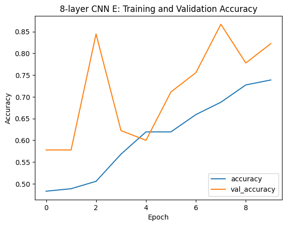

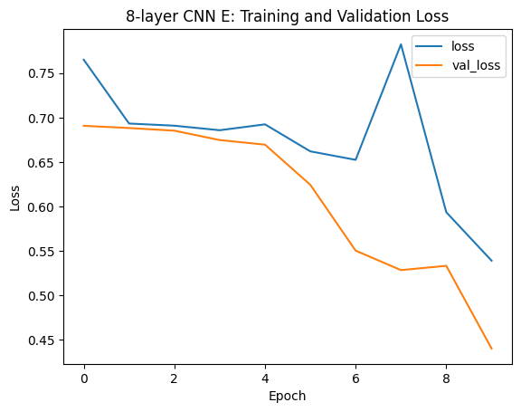

```python
plt.plot(history_8E.history["accuracy"])
plt.plot(history_8E.history["val_accuracy"])
plt.xlabel("Epoch")
plt.ylabel("Accuracy")
plt.legend(['accuracy', 'val_accuracy'], loc='lower right')
plt.title("8-layer CNN E: Training and Validation Accuracy")
plt.show()

plt.plot(history_8E.history["loss"])
plt.plot(history_8E.history["val_loss"])
plt.xlabel("Epoch")
plt.ylabel("Loss")
plt.legend(['loss', 'val_loss'], loc='upper right')
plt.title("8-layer CNN E: Training and Validation Loss")
plt.show()
```

```python
%%time

#Model 8F: increase batch size from 16 to 32
np.random.seed(1)
tf.random.set_seed(1)

model_8F = Sequential([
    Conv2D(filters=16, kernel_size=(3, 3), padding="same", activation="relu", input_shape=x_full_train.shape[1:]),
    MaxPooling2D(pool_size=(2, 2)),
    Conv2D(filters=32, kernel_size=(3, 3), padding="same", activation="relu"),
    MaxPooling2D(pool_size=(2, 2)),
    Conv2D(filters=64, kernel_size=(3, 3), padding="same", activation="relu"),
    MaxPooling2D(pool_size=(2, 2)),
    Conv2D(filters=128, kernel_size=(3, 3), padding="same", activation="relu"),
    MaxPooling2D(pool_size=(2, 2)),
    Flatten(),
    Dropout(rate=0.3),
    Dense(units=64, activation="relu"),
    Dense(units=1, activation="sigmoid")])

model_8F.compile(loss='binary_crossentropy',
                  optimizer='rmsprop',
                  metrics=['accuracy'])

history_8F = model_8F.fit(x_full_train, y_full_train,
            epochs=10,
            batch_size=32,
            validation_split=0.2,
            verbose=0)

train_score_8F = model_8F.evaluate(x_full_train, y_full_train, verbose=0)
test_score_8F = model_8F.evaluate(x_full_test, y_full_test, verbose=0)

print("Training Accuracy: {:.2f}%".format(train_score_8F[1] * 100))
print("Training Error: {:.2f}%".format((1 - train_score_8F[1]) * 100))
print("Test Accuracy: {:.2f}%".format(test_score_8F[1] * 100))
print("Test Error: {:.2f}%".format((1 - test_score_8F[1]) * 100))
```

```
Training Accuracy: 73.30%
Training Error: 26.70%
Test Accuracy: 72.63%
Test Error: 27.37%
CPU times: user 1min 41s, sys: 10.8 s, total: 1min 52s
Wall time: 25.9 s
```

```python
plt.plot(history_8F.history["accuracy"])
plt.plot(history_8F.history["val_accuracy"])
plt.xlabel("Epoch")
plt.ylabel("Accuracy")
plt.legend(['accuracy', 'val_accuracy'], loc='lower right')
plt.title("8-layer CNN F: Training and Validation Accuracy")
plt.show()

plt.plot(history_8F.history["loss"])
plt.plot(history_8F.history["val_loss"])
plt.xlabel("Epoch")
plt.ylabel("Loss")
plt.legend(['loss', 'val_loss'], loc='upper right')
plt.title("8-layer CNN F: Training and Validation Loss")
plt.show()
```

[output not shown]

Model 8E increased the dense layer from 64 to 128 units while keeping the same 8-layer CNN structure. The test error slightly incereased from 23.16% (for Model 8A, with 64 dense units) to 24.21% for Model 8E, suggesting that the larger dense layer did not improve the model's predictive performance. Model 8F increased the batch size from 16 to 32, produced a higher test error (27.37%). Increasing batch size did not improve the model's predictive performance, either. Hence, the smaller dense layer (with 64 units) and smaller batch size (of 16) were kept.

After fine-tuning, the best binary model to predict *amerob* vs. *bewwre* was Model 8A, a 8-layer CNN model, with filter setting of 16/32/64/128, dropout rate of 0.3, 64 dense units and 16 batch size. This model had a training error of 15.38 % (corresponding to a training accuracy of 84.62%) and a test error of 23.16% (corresponding to a test accuracy of 76.84%).

#### Multi-class Model

```python
#prepare dataset

random.seed(1)
np.random.seed(1)
tf.random.set_seed(1)

x_list = []
y_list = []

for label, species in enumerate(species_key_from_list):
    data = f[species]
    print(species, "original shape:", data.shape)
    selected_data = data[:, :, :]
    selected_data = np.moveaxis(selected_data, 2, 0)
    x_list.append(selected_data)
    y_list.extend([label] * selected_data.shape[0])

#combined all species into one dataset
x_multi = np.concatenate(x_list, axis=0)
y_multi = np.array(y_list)

print("x_multi shape:", x_multi.shape)
print("y_multi shape:", y_multi.shape)
print("Species labels:", species_key_from_list)
print("Class counts:", np.bincount(y_multi))
```

```
amecro original shape: (128, 517, 66)
amerob original shape: (128, 517, 172)
bewwre original shape: (128, 517, 144)
bkcchi original shape: (128, 517, 45)
daejun original shape: (128, 517, 125)
houfin original shape: (128, 517, 84)
houspa original shape: (128, 517, 630)
norfli original shape: (128, 517, 37)
rewbla original shape: (128, 517, 187)
sonspa original shape: (128, 517, 263)
spotow original shape: (128, 517, 137)
whcspa original shape: (128, 517, 91)
x_multi shape: (1981, 128, 517)
y_multi shape: (1981,)
Species labels: ['amecro', 'amerob', 'bewwre', 'bkcchi', 'daejun', 'houfin', 'houspa', 'norfli', 'rewbla', 'sonspa', 'spotow', 'whcspa']
Class counts: [ 66 172 144  45 125  84 630  37 187 263 137  91]
```

```python
#scale image to [0,1] range
x_multi = x_multi.astype("float32")
x_multi = (x_multi - x_multi.min()) / (x_multi.max() - x_multi.min())

# Add channel dimension for grayscale images
x_multi = np.expand_dims(x_multi, axis=-1)

#one-hot encoding
y_multi_cat = to_categorical(y_multi, 12)
print("One-hot y shape:", y_multi_cat.shape)
```

```
One-hot y shape: (1981, 12)
```

```python
#split into training (70%) and test (30%) sets
x_multi_train, x_multi_test, y_multi_train, y_multi_test = train_test_split(
    x_multi,
    y_multi_cat,
    test_size=0.30,
    random_state=1,
    stratify=y_multi)

print("x_multi_train shape:", x_multi_train.shape)
print("x_multi_test shape:", x_multi_test.shape)
print("y_multi_train shape:", y_multi_train.shape)
print("y_multi_test shape:", y_multi_test.shape)
```

```
x_multi_train shape: (1386, 128, 517, 1)
x_multi_test shape: (595, 128, 517, 1)
y_multi_train shape: (1386, 12)
y_multi_test shape: (595, 12)
```

```python
%%time

#fit multi-class CNN
#fit a 8-layer CNN model
np.random.seed(1)
tf.random.set_seed(1)

model_multi_8 = Sequential([
    Conv2D(filters=16, kernel_size=(3, 3), padding="same", activation="relu", input_shape=x_multi_train.shape[1:]),
    MaxPooling2D(pool_size=(2, 2)),
    Conv2D(filters=32, kernel_size=(3, 3), padding="same", activation="relu"),
    MaxPooling2D(pool_size=(2, 2)),
    Conv2D(filters=64, kernel_size=(3, 3), padding="same", activation="relu"),
    MaxPooling2D(pool_size=(2, 2)),
    Conv2D(filters=128, kernel_size=(3, 3), padding="same", activation="relu"),
    MaxPooling2D(pool_size=(2, 2)),
    Flatten(),
    Dropout(rate= 0.3),
    Dense(units=64, activation="relu"),
    Dense(units=12, activation="softmax")])

model_multi_8.compile(loss='categorical_crossentropy',
                  optimizer='rmsprop',
                  metrics=['accuracy'])

history_multi_8 = model_multi_8.fit(x_multi_train, y_multi_train,
            epochs=10,
            batch_size=16,
            validation_split=0.2,
            verbose=0)

train_score_multi_8 = model_multi_8.evaluate(x_multi_train, y_multi_train, verbose=0)
test_score_multi_8 = model_multi_8.evaluate(x_multi_test, y_multi_test, verbose=0)

print("Training Accuracy: {:.2f}%".format(train_score_multi_8[1] * 100))
print("Training Error: {:.2f}%".format((1 - train_score_multi_8[1]) * 100))
print("Test Accuracy: {:.2f}%".format(test_score_multi_8[1] * 100))
print("Test Error: {:.2f}%".format((1 - test_score_multi_8[1]) * 100))
```

```
Training Accuracy: 68.33%
Training Error: 31.67%
Test Accuracy: 46.89%
Test Error: 53.11%
CPU times: user 10min 44s, sys: 53.8 s, total: 11min 38s
Wall time: 2min 5s
```

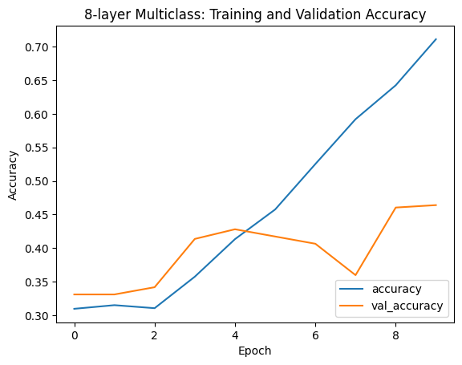

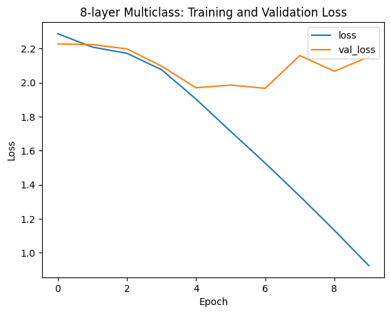

```python
plt.plot(history_multi_8.history["accuracy"])
plt.plot(history_multi_8.history["val_accuracy"])
plt.xlabel("Epoch")
plt.ylabel("Accuracy")
plt.legend(['accuracy', 'val_accuracy'], loc='lower right')
plt.title("8-layer Multiclass: Training and Validation Accuracy")
plt.show()

plt.plot(history_multi_8.history["loss"])
plt.plot(history_multi_8.history["val_loss"])
plt.xlabel("Epoch")
plt.ylabel("Loss")
plt.legend(['loss', 'val_loss'], loc='upper right')
plt.title("8-layer Multiclass: Training and Validation Loss")
plt.show()
```

For the 8-layer multiclass CNN, the training accuracy increased steadily while validation accuracy remained much lower, and validation loss increased after epoch = 6, which suggesting overfitting. Next, shallower CNN models (6-layer and 4-layer) were tested to see whether a simplier sturecture would perform better.

```python
%%time

#fit a 6-layer CNN model
np.random.seed(1)
tf.random.set_seed(1)

model_multi_6 = Sequential([
    Conv2D(filters=16, kernel_size=(3, 3), padding="same", activation="relu", input_shape=x_multi_train.shape[1:]),
    MaxPooling2D(pool_size=(2, 2)),
    Conv2D(filters=32, kernel_size=(3, 3), padding="same", activation="relu"),
    MaxPooling2D(pool_size=(2, 2)),
    Conv2D(filters=64, kernel_size=(3, 3), padding="same", activation="relu"),
    MaxPooling2D(pool_size=(2, 2)),
    Flatten(),
    Dropout(rate= 0.3),
    Dense(units=64, activation="relu"),
    Dense(units=12, activation="softmax")])

model_multi_6.compile(loss='categorical_crossentropy',
                  optimizer='rmsprop',
                  metrics=['accuracy'])

history_multi_6 = model_multi_6.fit(x_multi_train, y_multi_train,
            epochs=10,
            batch_size=16,
            validation_split=0.2,
            verbose=0)

train_score_multi_6 = model_multi_6.evaluate(x_multi_train, y_multi_train, verbose=0)
test_score_multi_6 = model_multi_6.evaluate(x_multi_test, y_multi_test, verbose=0)

print("Training Accuracy: {:.2f}%".format(train_score_multi_6[1] * 100))
print("Training Error: {:.2f}%".format((1 - train_score_multi_6[1]) * 100))
print("Test Accuracy: {:.2f}%".format(test_score_multi_6[1] * 100))
print("Test Error: {:.2f}%".format((1 - test_score_multi_6[1]) * 100))
```

```
Training Accuracy: 64.29%
Training Error: 35.71%
Test Accuracy: 42.18%
Test Error: 57.82%
CPU times: user 8min 58s, sys: 48.8 s, total: 9min 46s
Wall time: 1min 41s
```

```python
%%time

#fit a 4-layer CNN model
np.random.seed(1)
tf.random.set_seed(1)

model_multi_4 = Sequential([
    Conv2D(filters=16, kernel_size=(3, 3), padding="same", activation="relu", input_shape=x_multi_train.shape[1:]),
    MaxPooling2D(pool_size=(2, 2)),
    Conv2D(filters=32, kernel_size=(3, 3), padding="same", activation="relu"),
    MaxPooling2D(pool_size=(2, 2)),
    Flatten(),
    Dropout(rate= 0.3),
    Dense(units=64, activation="relu"),
    Dense(units=12, activation="softmax")])

model_multi_4.compile(loss='categorical_crossentropy',
                  optimizer='rmsprop',
                  metrics=['accuracy'])

history_multi_4 = model_multi_4.fit(x_multi_train, y_multi_train,
            epochs=10,
            batch_size=16,
            validation_split=0.2,
            verbose=0)

train_score_multi_4 = model_multi_4.evaluate(x_multi_train, y_multi_train, verbose=0)
test_score_multi_4 = model_multi_4.evaluate(x_multi_test, y_multi_test, verbose=0)

print("Training Accuracy: {:.2f}%".format(train_score_multi_4[1] * 100))
print("Training Error: {:.2f}%".format((1 - train_score_multi_4[1]) * 100))
print("Test Accuracy: {:.2f}%".format(test_score_multi_4[1] * 100))
print("Test Error: {:.2f}%".format((1 - test_score_multi_4[1]) * 100))
```

```
Training Accuracy: 71.07%
Training Error: 28.93%
Test Accuracy: 37.65%
Test Error: 62.35%
CPU times: user 7min 15s, sys: 41.1 s, total: 7min 57s
Wall time: 1min 23s
```

Among the three tested models, the 8-layer model performed the best, with a test error of 53.11%, lower than 62.35% of the 4-layer model and 57.82% of the 6-layer model. Although showing signs of overfitting, the 8-layer CNN was still the optimal depth, and further tuning is needed to improve the model performance.

According to Xia (2024), there are a few options to reduce overfitt of a CNN model, including **L2 regularization** and **dropout**. Next, **L2 regularization** was tested, with values of 0.001 and 0.0001:

```python
%%time

np.random.seed(1)
tf.random.set_seed(1)

model_multi_8A = Sequential([
    Conv2D(filters=16, kernel_size=(3, 3), padding="same", activation="relu", input_shape=x_multi_train.shape[1:]),
    MaxPooling2D(pool_size=(2, 2)),
    Conv2D(filters=32, kernel_size=(3, 3), padding="same", activation="relu"),
    MaxPooling2D(pool_size=(2, 2)),
    Conv2D(filters=64, kernel_size=(3, 3), padding="same", activation="relu"),
    MaxPooling2D(pool_size=(2, 2)),
    Conv2D(filters=128, kernel_size=(3, 3), padding="same", activation="relu"),
    MaxPooling2D(pool_size=(2, 2)),
    Flatten(),
    Dropout(rate= 0.3),
    #use L2 regularization on dense layer to reduce overfit
    Dense(units=64, activation="relu", kernel_regularizer=regularizers.l2(0.001)),
    Dense(units=12, activation="softmax")])


model_multi_8A.compile(loss='categorical_crossentropy',
                  optimizer='rmsprop',
                  metrics=['accuracy'])

history_multi_8A = model_multi_8A.fit(x_multi_train, y_multi_train,
            epochs=10,
            batch_size=16,
            validation_split=0.2,
            verbose=0)

train_score_multi_8A = model_multi_8A.evaluate(x_multi_train, y_multi_train, verbose=0)
test_score_multi_8A = model_multi_8A.evaluate(x_multi_test, y_multi_test, verbose=0)

print("Training Accuracy: {:.2f}%".format(train_score_multi_8A[1] * 100))
print("Training Error: {:.2f}%".format((1 - train_score_multi_8A[1]) * 100))
print("Test Accuracy: {:.2f}%".format(test_score_multi_8A[1] * 100))
print("Test Error: {:.2f}%".format((1 - test_score_multi_8A[1]) * 100))
```

```
Training Accuracy: 65.51%
Training Error: 34.49%
Test Accuracy: 44.71%
Test Error: 55.29%
CPU times: user 10min 49s, sys: 59.1 s, total: 11min 48s
Wall time: 2min 15s
```

```python
%%time

np.random.seed(1)
tf.random.set_seed(1)
#use L2 regularization on both convolution and dense layers to reduce overfit
model_multi_8A1 = Sequential([
    Conv2D(filters=16, kernel_size=(3, 3), padding="same", activation="relu", input_shape=x_multi_train.shape[1:],kernel_regularizer=regularizers.l2(0.001)),
    MaxPooling2D(pool_size=(2, 2)),
    Conv2D(filters=32, kernel_size=(3, 3), padding="same", activation="relu", kernel_regularizer=regularizers.l2(0.001)),
    MaxPooling2D(pool_size=(2, 2)),
    Conv2D(filters=64, kernel_size=(3, 3), padding="same", activation="relu", kernel_regularizer=regularizers.l2(0.001)),
    MaxPooling2D(pool_size=(2, 2)),
    Conv2D(filters=128, kernel_size=(3, 3), padding="same", activation="relu", kernel_regularizer=regularizers.l2(0.001)),
    MaxPooling2D(pool_size=(2, 2)),
    Flatten(),
    Dropout(rate= 0.3),
    Dense(units=64, activation="relu", kernel_regularizer=regularizers.l2(0.001)),
    Dense(units=12, activation="softmax")])


model_multi_8A1.compile(loss='categorical_crossentropy',
                  optimizer='rmsprop',
                  metrics=['accuracy'])

history_multi_8A1 = model_multi_8A1.fit(x_multi_train, y_multi_train,
            epochs=10,
            batch_size=16,
            validation_split=0.2,
            verbose=0)

train_score_multi_8A1 = model_multi_8A1.evaluate(x_multi_train, y_multi_train, verbose=0)
test_score_multi_8A1 = model_multi_8A1.evaluate(x_multi_test, y_multi_test, verbose=0)

print("Training Accuracy: {:.2f}%".format(train_score_multi_8A1[1] * 100))
print("Training Error: {:.2f}%".format((1 - train_score_multi_8A1[1]) * 100))
print("Test Accuracy: {:.2f}%".format(test_score_multi_8A1[1] * 100))
print("Test Error: {:.2f}%".format((1 - test_score_multi_8A1[1]) * 100))
```

```
Training Accuracy: 62.19%
Training Error: 37.81%
Test Accuracy: 43.19%
Test Error: 56.81%
CPU times: user 10min 48s, sys: 55 s, total: 11min 43s
Wall time: 2min 3s
```

```python
np.random.seed(1)
tf.random.set_seed(1)
#use L2 regularization on convolution layers to reduce overfit
model_multi_8A2 = Sequential([
    Conv2D(filters=16, kernel_size=(3, 3), padding="same", activation="relu", input_shape=x_multi_train.shape[1:],kernel_regularizer=regularizers.l2(0.001)),
    MaxPooling2D(pool_size=(2, 2)),
    Conv2D(filters=32, kernel_size=(3, 3), padding="same", activation="relu", kernel_regularizer=regularizers.l2(0.001)),
    MaxPooling2D(pool_size=(2, 2)),
    Conv2D(filters=64, kernel_size=(3, 3), padding="same", activation="relu", kernel_regularizer=regularizers.l2(0.001)),
    MaxPooling2D(pool_size=(2, 2)),
    Conv2D(filters=128, kernel_size=(3, 3), padding="same", activation="relu", kernel_regularizer=regularizers.l2(0.001)),
    MaxPooling2D(pool_size=(2, 2)),
    Flatten(),
    Dropout(rate= 0.3),
    Dense(units=64, activation="relu"),
    Dense(units=12, activation="softmax")])


model_multi_8A2.compile(loss='categorical_crossentropy',
                  optimizer='rmsprop',
                  metrics=['accuracy'])

history_multi_8A2 = model_multi_8A2.fit(x_multi_train, y_multi_train,
            epochs=10,
            batch_size=16,
            validation_split=0.2,
            verbose=0)

train_score_multi_8A2 = model_multi_8A2.evaluate(x_multi_train, y_multi_train, verbose=0)
test_score_multi_8A2 = model_multi_8A2.evaluate(x_multi_test, y_multi_test, verbose=0)

print("Training Accuracy: {:.2f}%".format(train_score_multi_8A2[1] * 100))
print("Training Error: {:.2f}%".format((1 - train_score_multi_8A2[1]) * 100))
print("Test Accuracy: {:.2f}%".format(test_score_multi_8A2[1] * 100))
print("Test Error: {:.2f}%".format((1 - test_score_multi_8A2[1]) * 100))
```

```
Training Accuracy: 53.39%
Training Error: 46.61%
Test Accuracy: 42.86%
Test Error: 57.14%
```

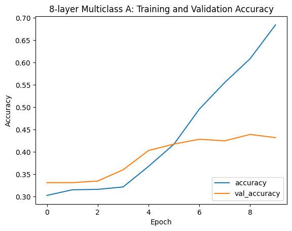

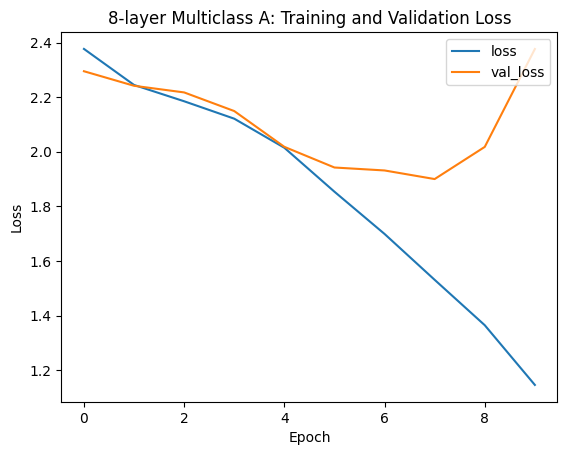

```python
plt.plot(history_multi_8A.history["accuracy"])
plt.plot(history_multi_8A.history["val_accuracy"])
plt.xlabel("Epoch")
plt.ylabel("Accuracy")
plt.legend(['accuracy', 'val_accuracy'], loc='lower right')
plt.title("8-layer Multiclass A: Training and Validation Accuracy")
plt.show()

plt.plot(history_multi_8A.history["loss"])
plt.plot(history_multi_8A.history["val_loss"])
plt.xlabel("Epoch")
plt.ylabel("Loss")
plt.legend(['loss', 'val_loss'], loc='upper right')
plt.title("8-layer Multiclass A: Training and Validation Loss")
plt.show()
```

L2 regularization (on dense layer, convolution layers, and both convolution and dense layers) did not improve the original 8-layer muticlass CNN, with test error ranging from 55.29% to 57.14%. The training curves of model 8A suggest that the model was learning useful patterns, as training accuracy increased and training loss decreased. However, the validation loss began increasing after about epoch 7, which indicated overfitting. These results suggested that L2 regulation did not substantially reduce overfitting. Also, it sugguested that **early stopping** around the point where validation loss was lowest (i.e., epoch = 6 or 7) may further improve generalization.

```python
%%time

np.random.seed(1)
tf.random.set_seed(1)
#add early stopping to prevent overfitting and reduce training time
early_stop = EarlyStopping(
    monitor="val_loss",
    patience=2,
    restore_best_weights=True)

model_multi_8B = Sequential([
    Conv2D(filters=16, kernel_size=(3, 3), padding="same", activation="relu", input_shape=x_multi_train.shape[1:]),
    MaxPooling2D(pool_size=(2, 2)),
    Conv2D(filters=32, kernel_size=(3, 3), padding="same", activation="relu"),
    MaxPooling2D(pool_size=(2, 2)),
    Conv2D(filters=64, kernel_size=(3, 3), padding="same", activation="relu"),
    MaxPooling2D(pool_size=(2, 2)),
    Conv2D(filters=128, kernel_size=(3, 3), padding="same", activation="relu"),
    MaxPooling2D(pool_size=(2, 2)),
    Flatten(),
    Dropout(rate= 0.3),
    Dense(units=64, activation="relu"),
    Dense(units=12, activation="softmax")])

model_multi_8B.compile(loss='categorical_crossentropy',
                  optimizer='rmsprop',
                  metrics=['accuracy'])

history_multi_8B = model_multi_8B.fit(x_multi_train, y_multi_train,
            epochs=10,
            batch_size=16,
            validation_split=0.2,
            #add early stopping with patience of 2
            callbacks=[early_stop],
            verbose=0)

train_score_multi_8B = model_multi_8B.evaluate(x_multi_train, y_multi_train, verbose=0)
test_score_multi_8B = model_multi_8B.evaluate(x_multi_test, y_multi_test, verbose=0)

print("Training Accuracy: {:.2f}%".format(train_score_multi_8B[1] * 100))
print("Training Error: {:.2f}%".format((1 - train_score_multi_8B[1]) * 100))
print("Test Accuracy: {:.2f}%".format(test_score_multi_8B[1] * 100))
print("Test Error: {:.2f}%".format((1 - test_score_multi_8B[1]) * 100))
```

```
Training Accuracy: 51.30%
Training Error: 48.70%
Test Accuracy: 43.53%
Test Error: 56.47%
CPU times: user 8min 39s, sys: 40.2 s, total: 9min 19s
Wall time: 1min 34s
```

```python
%%time

np.random.seed(1)
tf.random.set_seed(1)
#add early stopping to prevent overfitting and reduce training time
early_stop = EarlyStopping(
    monitor="val_loss",
    patience=1,
    restore_best_weights=True)

model_multi_8B1 = Sequential([
    Conv2D(filters=16, kernel_size=(3, 3), padding="same", activation="relu", input_shape=x_multi_train.shape[1:]),
    MaxPooling2D(pool_size=(2, 2)),
    Conv2D(filters=32, kernel_size=(3, 3), padding="same", activation="relu"),
    MaxPooling2D(pool_size=(2, 2)),
    Conv2D(filters=64, kernel_size=(3, 3), padding="same", activation="relu"),
    MaxPooling2D(pool_size=(2, 2)),
    Conv2D(filters=128, kernel_size=(3, 3), padding="same", activation="relu"),
    MaxPooling2D(pool_size=(2, 2)),
    Flatten(),
    Dropout(rate= 0.3),
    Dense(units=64, activation="relu"),
    Dense(units=12, activation="softmax")])

model_multi_8B1.compile(loss='categorical_crossentropy',
                  optimizer='rmsprop',
                  metrics=['accuracy'])

history_multi_8B1 = model_multi_8B1.fit(x_multi_train, y_multi_train,
            epochs=10,
            batch_size=16,
            validation_split=0.2,
            #add early stopping with patience of 1
            callbacks=[early_stop],
            verbose=0)

train_score_multi_8B1 = model_multi_8B1.evaluate(x_multi_train, y_multi_train, verbose=0)
test_score_multi_8B1 = model_multi_8B1.evaluate(x_multi_test, y_multi_test, verbose=0)

print("Training Accuracy: {:.2f}%".format(train_score_multi_8B1[1] * 100))
print("Training Error: {:.2f}%".format((1 - train_score_multi_8B1[1]) * 100))
print("Test Accuracy: {:.2f}%".format(test_score_multi_8B1[1] * 100))
print("Test Error: {:.2f}%".format((1 - test_score_multi_8B1[1]) * 100))
```

```
Training Accuracy: 31.96%
Training Error: 68.04%
Test Accuracy: 31.93%
Test Error: 68.07%
CPU times: user 3min 33s, sys: 17.1 s, total: 3min 50s
Wall time: 38.9 s
```

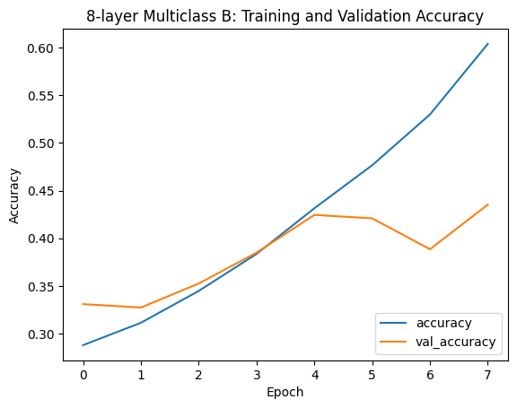

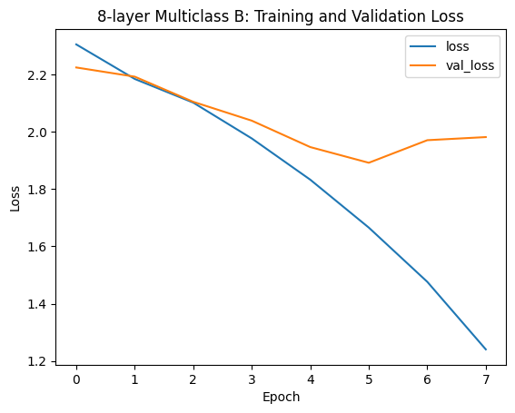

```python
plt.plot(history_multi_8B.history["accuracy"])
plt.plot(history_multi_8B.history["val_accuracy"])
plt.xlabel("Epoch")
plt.ylabel("Accuracy")
plt.legend(['accuracy', 'val_accuracy'], loc='lower right')
plt.title("8-layer Multiclass B: Training and Validation Accuracy")
plt.show()

plt.plot(history_multi_8B.history["loss"])
plt.plot(history_multi_8B.history["val_loss"])
plt.xlabel("Epoch")
plt.ylabel("Loss")
plt.legend(['loss', 'val_loss'], loc='upper right')
plt.title("8-layer Multiclass B: Training and Validation Loss")
plt.show()
```

```python
%%time

np.random.seed(1)
tf.random.set_seed(1)

model_multi_8C = Sequential([
    Conv2D(filters=16, kernel_size=(3, 3), padding="same", activation="relu", input_shape=x_multi_train.shape[1:]),
    MaxPooling2D(pool_size=(2, 2)),
    Conv2D(filters=32, kernel_size=(3, 3), padding="same", activation="relu"),
    MaxPooling2D(pool_size=(2, 2)),
    Conv2D(filters=64, kernel_size=(3, 3), padding="same", activation="relu"),
    MaxPooling2D(pool_size=(2, 2)),
    Conv2D(filters=128, kernel_size=(3, 3), padding="same", activation="relu"),
    MaxPooling2D(pool_size=(2, 2)),
    Flatten(),
    #increase dropout rate from 0.3 to 0.5
    Dropout(rate= 0.5),
    Dense(units=64, activation="relu"),
    Dense(units=12, activation="softmax")])

model_multi_8C.compile(loss='categorical_crossentropy',
                  optimizer='rmsprop',
                  metrics=['accuracy'])

history_multi_8C = model_multi_8C.fit(x_multi_train, y_multi_train,
            epochs=10,
            batch_size=16,
            validation_split=0.2,
            verbose=0)

train_score_multi_8C = model_multi_8C.evaluate(x_multi_train, y_multi_train, verbose=0)
test_score_multi_8C = model_multi_8C.evaluate(x_multi_test, y_multi_test, verbose=0)

print("Training Accuracy: {:.2f}%".format(train_score_multi_8C[1] * 100))
print("Training Error: {:.2f}%".format((1 - train_score_multi_8C[1]) * 100))
print("Test Accuracy: {:.2f}%".format(test_score_multi_8C[1] * 100))
print("Test Error: {:.2f}%".format((1 - test_score_multi_8C[1]) * 100))
```

```
Training Accuracy: 67.53%
Training Error: 32.47%
Test Accuracy: 45.55%
Test Error: 54.45%
CPU times: user 10min 37s, sys: 52.4 s, total: 11min 30s
Wall time: 2min 3s
```

```python
%%time

np.random.seed(1)
tf.random.set_seed(1)

model_multi_8C1 = Sequential([
    Conv2D(filters=16, kernel_size=(3, 3), padding="same", activation="relu", input_shape=x_multi_train.shape[1:]),
    MaxPooling2D(pool_size=(2, 2)),
    Conv2D(filters=32, kernel_size=(3, 3), padding="same", activation="relu"),
    MaxPooling2D(pool_size=(2, 2)),
    Conv2D(filters=64, kernel_size=(3, 3), padding="same", activation="relu"),
    MaxPooling2D(pool_size=(2, 2)),
    Conv2D(filters=128, kernel_size=(3, 3), padding="same", activation="relu"),
    MaxPooling2D(pool_size=(2, 2)),
    Flatten(),
    #decrease dropout rate from 0.3 to 0.2
    Dropout(rate= 0.2),
    Dense(units=64, activation="relu"),
    Dense(units=12, activation="softmax")])

model_multi_8C1.compile(loss='categorical_crossentropy',
                  optimizer='rmsprop',
                  metrics=['accuracy'])

history_multi_8C1 = model_multi_8C1.fit(x_multi_train, y_multi_train,
            epochs=10,
            batch_size=16,
            validation_split=0.2,
            verbose=0)

train_score_multi_8C1 = model_multi_8C1.evaluate(x_multi_train, y_multi_train, verbose=0)
test_score_multi_8C1 = model_multi_8C1.evaluate(x_multi_test, y_multi_test, verbose=0)

print("Training Accuracy: {:.2f}%".format(train_score_multi_8C1[1] * 100))
print("Training Error: {:.2f}%".format((1 - train_score_multi_8C1[1]) * 100))
print("Test Accuracy: {:.2f}%".format(test_score_multi_8C1[1] * 100))
print("Test Error: {:.2f}%".format((1 - test_score_multi_8C1[1]) * 100))
```

```
Training Accuracy: 63.13%
Training Error: 36.87%
Test Accuracy: 43.87%
Test Error: 56.13%
CPU times: user 10min 45s, sys: 51.7 s, total: 11min 37s
Wall time: 2min
```

```python
%%time

np.random.seed(1)
tf.random.set_seed(1)

model_multi_8C2 = Sequential([
    Conv2D(filters=16, kernel_size=(3, 3), padding="same", activation="relu", input_shape=x_multi_train.shape[1:]),
    MaxPooling2D(pool_size=(2, 2)),
    Conv2D(filters=32, kernel_size=(3, 3), padding="same", activation="relu"),
    MaxPooling2D(pool_size=(2, 2)),
    Conv2D(filters=64, kernel_size=(3, 3), padding="same", activation="relu"),
    MaxPooling2D(pool_size=(2, 2)),
    Conv2D(filters=128, kernel_size=(3, 3), padding="same", activation="relu"),
    MaxPooling2D(pool_size=(2, 2)),
    Flatten(),
    #increase dropout rate from 0.3 to 0.4
    Dropout(rate= 0.4),
    Dense(units=64, activation="relu"),
    Dense(units=12, activation="softmax")])

model_multi_8C2.compile(loss='categorical_crossentropy',
                  optimizer='rmsprop',
                  metrics=['accuracy'])

history_multi_8C2 = model_multi_8C2.fit(x_multi_train, y_multi_train,
            epochs=10,
            batch_size=16,
            validation_split=0.2,
            verbose=0)

train_score_multi_8C2 = model_multi_8C2.evaluate(x_multi_train, y_multi_train, verbose=0)
test_score_multi_8C2 = model_multi_8C2.evaluate(x_multi_test, y_multi_test, verbose=0)

print("Training Accuracy: {:.2f}%".format(train_score_multi_8C2[1] * 100))
print("Training Error: {:.2f}%".format((1 - train_score_multi_8C2[1]) * 100))
print("Test Accuracy: {:.2f}%".format(test_score_multi_8C2[1] * 100))
print("Test Error: {:.2f}%".format((1 - test_score_multi_8C2[1]) * 100))
```

```
Training Accuracy: 69.84%
Training Error: 30.16%
Test Accuracy: 45.38%
Test Error: 54.62%
CPU times: user 10min 33s, sys: 49.9 s, total: 11min 23s
Wall time: 2min 3s
```

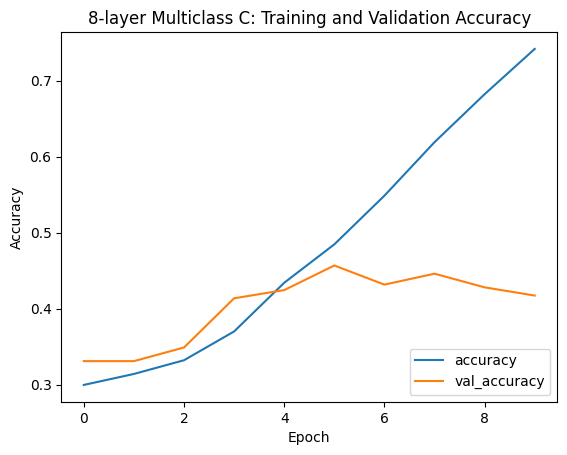

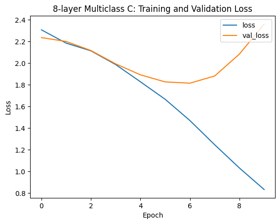

```python
plt.plot(history_multi_8C.history["accuracy"])
plt.plot(history_multi_8C.history["val_accuracy"])
plt.xlabel("Epoch")
plt.ylabel("Accuracy")
plt.legend(['accuracy', 'val_accuracy'], loc='lower right')
plt.title("8-layer Multiclass C: Training and Validation Accuracy")
plt.show()

plt.plot(history_multi_8C.history["loss"])
plt.plot(history_multi_8C.history["val_loss"])
plt.xlabel("Epoch")
plt.ylabel("Loss")
plt.legend(['loss', 'val_loss'], loc='upper right')
plt.title("8-layer Multiclass C: Training and Validation Loss")
plt.show()
```

Different dropout values (0.5, 0.2, 0.4) were tested. The model produce a test error of 54.45%, 56.13%, and 54.62% respectively, which were worse than the model with dropout = 0.3. The validation loss decreased early in the training but began increasing again near the later epochs while training loss continued to decress. This suggests that increasing a higher (or lower) dropout value did not prevent overfitting or improve predictive performance. The dropout of 0.3 was kept.

Next, a higher **batch size** was tested, to make the training more stable.

```python
%%time

np.random.seed(1)
tf.random.set_seed(1)

model_multi_8D = Sequential([
    Conv2D(filters=16, kernel_size=(3, 3), padding="same", activation="relu", input_shape=x_multi_train.shape[1:]),
    MaxPooling2D(pool_size=(2, 2)),
    Conv2D(filters=32, kernel_size=(3, 3), padding="same", activation="relu"),
    MaxPooling2D(pool_size=(2, 2)),
    Conv2D(filters=64, kernel_size=(3, 3), padding="same", activation="relu"),
    MaxPooling2D(pool_size=(2, 2)),
    Conv2D(filters=128, kernel_size=(3, 3), padding="same", activation="relu"),
    MaxPooling2D(pool_size=(2, 2)),
    Flatten(),
    Dropout(rate= 0.3),
    Dense(units=64, activation="relu"),
    Dense(units=12, activation="softmax")])

model_multi_8D.compile(loss='categorical_crossentropy',
                  optimizer='rmsprop',
                  metrics=['accuracy'])

history_multi_8D = model_multi_8D.fit(x_multi_train, y_multi_train,
            epochs=10,
            #a higher batch size was tested
            batch_size=32,
            validation_split=0.2,
            verbose=0)

train_score_multi_8D = model_multi_8D.evaluate(x_multi_train, y_multi_train, verbose=0)
test_score_multi_8D = model_multi_8D.evaluate(x_multi_test, y_multi_test, verbose=0)

print("Training Accuracy: {:.2f}%".format(train_score_multi_8D[1] * 100))
print("Training Error: {:.2f}%".format((1 - train_score_multi_8D[1]) * 100))
print("Test Accuracy: {:.2f}%".format(test_score_multi_8D[1] * 100))
print("Test Error: {:.2f}%".format((1 - test_score_multi_8D[1]) * 100))
```

```
Training Accuracy: 51.15%
Training Error: 48.85%
Test Accuracy: 41.18%
Test Error: 58.82%
CPU times: user 10min 43s, sys: 1min 4s, total: 11min 47s
Wall time: 2min 15s
```

A higher batch size did not improve the model's predictive performance, with a higher test error rate of 58.82%. The lower batch size (16) was retained.